# Maine Climate Trends

Author

Natalie Smith and Liv Hemond

Published

April 11, 2025

# 1 Introduction –> LIV

## 1.1 Research Questions

Are the winters getting warmer in Maine? Is snowfall decreasing? Are extreme rainfall events increase in size or frequency? Is the hottest day of the year getting hotter?

# 2 Methods

## 2.1 Data exploration and cleaning

```r
# set up:

# load libraries
library(tidyverse)
library(here)
library(kableExtra)
library(lubridate)
library(Kendall)
library(patchwork)

# color palette:
tmax = "darkorange2"
tmin = "dodgerblue"
snow = "mediumorchid3"
precip = "steelblue"

# read in the data and clean names:
climate <- read_csv(here("data", "ncei_cdo_bangor_ME.csv")) %>%
  janitor::clean_names() %>%
  mutate(year = year(date)) %>%
  # remove the year 2025 since it's incomplete
  filter(year!= 2025)
```

```r
# exploratory plots - max. temp

ggplot(climate, aes(date, tmax)) +
  geom_line() +
  labs(y="Daily Maximum Temperature (degrees F)", x="Date")
```

```r
# exploratory plots - min. temp

ggplot(climate, aes(date, tmin)) +
  geom_line() +
  labs(y="Daily Minimum Temperature (degrees F)", x="Date")
```

```r
# exploratory plots - precipitation

ggplot(climate, aes(date, prcp)) +
  geom_line() +
  labs(y="Daily Rainfall (in)", x="Date")
```

```r
# exploratory plots - snowfall

ggplot(climate, aes(date, snow)) +
  geom_line() +
  labs(y="Daily Snowfall (in)", x="Date")
```

After running some exploratory plots and examining the data more closely, we found approximately 300 missing values. Where possible, we filled these NAs using the average of the preceding and following days. For large stretches of missing snow values during the summer months—when we assumed there was no snow—we replaced the NAs with zeros. Any remaining NAs that couldn’t be reasonably filled were dropped from the dataset.

```r
# replace NAs with the average of the previous day and following day in the climate dataset.
climate_clean <- climate %>%
  mutate(tmax = ifelse(is.na(tmax), (lag(tmax) + lead(tmax)) / 2, tmax),
         tmin = ifelse(is.na(tmin), (lag(tmin) + lead(tmin)) / 2, tmin),
         prcp = ifelse(is.na(prcp), (lag(prcp) + lead(prcp)) / 2, prcp),
         snow = ifelse(is.na(snow), (lag(snow) + lead(snow)) / 2, snow))

# if NA is in snow column, replace with a 0
climate_clean <- climate_clean %>%
  mutate(snow = ifelse(is.na(snow), 0, snow))

# remove remaining NAs
climate_clean <- climate_clean %>%
  drop_na()
# check to see if there are any lingering NAs (replace prcp with tmax, tmin, snow to check others)
sum(is.na(climate_clean$prcp))

# plot, as above
ggplot(climate_clean, aes(date, tmax)) +
  geom_line() +
  labs(y="Daily Maximum Temperature (degrees F)", x="Date")
```

# 3 Trend Analysis

## 3.1 Annual trends

We calculated annual climate summaries by averaging daily maximum and minimum temperatures, and summing daily precipitation and snowfall. To assess trends over time, we visualized annual tmax and tmin with line plots and added a line of best fit. We then performed linear regressions and Mann-Kendall tests for tmax, tmin, snowfall, and precipitation to evaluate the strength and significance of the trends.

```r
# calculate the annual mean temperature, remove duplicate rows so that there's only one row of average values per year
climate_annual <- climate_clean %>%
  mutate(year = year(date)) %>%
  group_by(year) %>%
  summarise(tmax = mean(tmax, na.rm = TRUE),
            tmin = mean(tmin, na.rm = TRUE),
            prcp = sum(prcp, na.rm = TRUE),
            snow = sum(snow, na.rm = TRUE))
```

### 3.1.1 Temperature

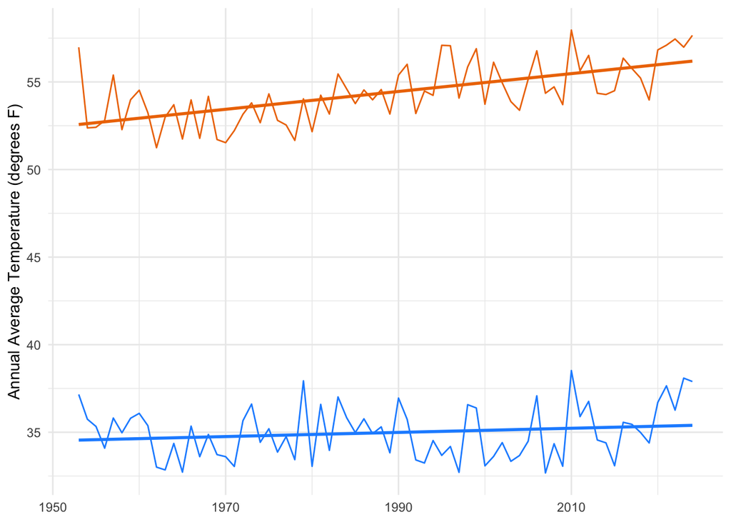

```r
# plot the annual average tmax and the annual average tmin on the same graph
# ggplot(climate_annual, aes(year)) +
#   geom_line(aes(y = tmax), color = "red") +
#   geom_line(aes(y = tmin), color = "blue") +
#   labs(y="Annual Average Temperature (degrees F)", x="Year")

# now let's put a trend line on this thing
temp_trend <- ggplot(climate_annual, aes(year)) +
  geom_line(aes(y = tmax), color = "darkorange2") +
  geom_line(aes(y = tmin), color = "dodgerblue") +
  geom_smooth(aes(y = tmax), method = "lm", color = "darkorange2", se = FALSE) +
  geom_smooth(aes(y = tmin), method = "lm", color = "dodgerblue", se = FALSE) +
  labs(y = "Annual Average Temperature (degrees F)", x = "Year") +
  scale_y_continuous(breaks = seq(30, 70, by = 5)) +
  theme_minimal() +
  theme(axis.title.x = element_blank())

temp_trend
```

### 3.1.2 Precipitation and Snowfall

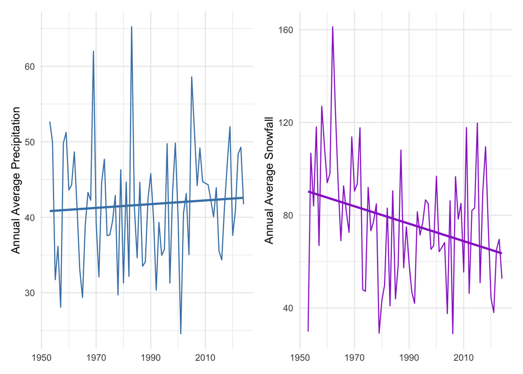

```r
# Plot for precipitation
precip_plot <- ggplot(climate_annual, aes(year)) +
  geom_line(aes(y = prcp, color = "Precipitation")) +
  geom_smooth(aes(y = prcp, color = "Precipitation"), method = "lm", se = FALSE) +
  labs(y = "Annual Average Precipitation",
       x = "Year") +
  scale_color_manual(values = c("Precipitation" = "steelblue")) +
  theme_minimal() +
  theme(axis.title.x = element_blank(),
        legend.position = "none")  # Remove legend

# Plot for snowfall
snow_plot <- ggplot(climate_annual, aes(year)) +
  geom_line(aes(y = snow, color = "Snowfall")) +
  geom_smooth(aes(y = snow, color = "Snowfall"), method = "lm", se = FALSE) +
  labs(y = "Annual Average Snowfall",
       x = "Year") +
  scale_color_manual(values = c("Snowfall" = "darkorchid3")) +
  theme_minimal() +
  theme(axis.title.x = element_blank(),
        legend.position = "none")  # Remove legend

# Combine the plots with patchwork
combined_plot <- precip_plot + snow_plot

combined_plot
```

We used linear regression to evaluate trends in annual minimum temperature, maximum temperature, total snowfall, and total precipitation over time. Each variable was modeled as a function of year to estimate the direction and rate of change. We also conducted Mann-Kendall trend tests for each variable to assess the presence and strength of trends without assuming a linear relationship or normal distribution.

```r
# let's do a linear regression for tmin over time. then do the same for tmax, snow, and prcp
summary(lm(tmin ~ year, data = climate_annual))
# slope is 0.012 F/year, and is not statistically significant

summary(lm(tmax ~ year, data = climate_annual))
# slope is 0.051 F/year, and is statistically significant

summary(lm(snow ~ year, data = climate_annual))
# slope is -0.376 in/year, and is statistically significant

summary(lm(prcp ~ year, data = climate_annual))
# slope is 0.025 in/year, and is not statistically significant
```

```r
# now let's do a Mann-Kendall test for tmax, tmin, snow, and prcp
# tmax
MannKendall(climate_annual$tmax)
# tau = 0.458, 2-sided pvalue =< 2.22e-16. moderately strong positive trend, statistically significant

# tmin
MannKendall(climate_annual$tmin)
# tau = 0.0771, 2-sided pvalue =0.34068. weak positive trend, not statistically significant

# snow
MannKendall(climate_annual$snow)
# tau = -0.201, 2-sided pvalue =0.012806. weak negative trend, statistically significant

# prcp
MannKendall(climate_annual$prcp)
# tau = 0.063, 2-sided pvalue =0.43668. weak positive trend, not statistically significant
```

### 3.1.3 Annual trends results:

Maximum temperature showed a statistically significant increasing trend over time, with an estimated increase of 0.051°F per year. The Mann-Kendall test confirmed this with a moderately strong, significant upward trend. Minimum temperature had an increase of 0.012°F per year, but this trend was not statistically significant in either test. Snowfall decreased significantly at a rate of 0.376 inches per year, supported by a weak but significant negative trend in the Mann-Kendall test. Precipitation showed a small, non-significant upward trend in both analyses.

## 3.2 Seasonal Trends

The annual trends showed us that maximum temperatures are increasing and snowfall is decreasing. To further explore these trends, we focused on seasonal averages for winter months (December, January, February) to see if the patterns hold true.

```r
# Focus on winter --> December, January, and February
# Create a new column for the month, filter for winter months, then calculate seasonal averages and means for each year, as we did above
climate_winter <- climate_clean %>%
  mutate(month = month(date)) %>%
  filter(month == 12 | month == 1 | month == 2) %>%
  mutate(season_year = year(date) + if_else(month == 12, 1, 0)) %>% #since december is in a previous year, we need to add 1 to the year to make dec, jan, feb all the same year
  # if December add 1, if not add 0
  group_by(season_year) %>%
  summarize(tmax = mean(tmax, na.rm = TRUE),
            tmin = mean(tmin, na.rm = TRUE),
            prcp = sum(prcp, na.rm = TRUE),
            snow = sum(snow, na.rm = TRUE))
```

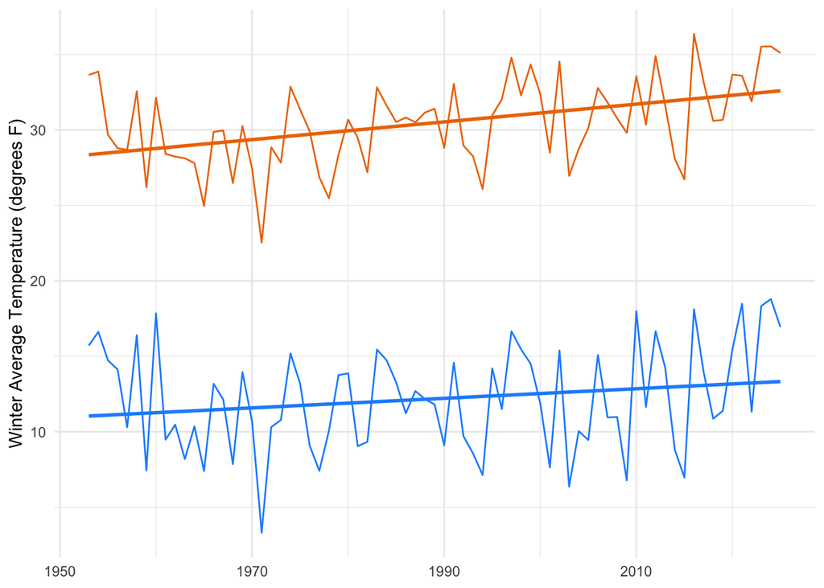

```r
# plot the winter average tmax and the winter average tmin on the same graph
winter_temp_plot <- ggplot(climate_winter, aes(season_year)) +
  geom_line(aes(y = tmax), color = "darkorange2") +
  geom_line(aes(y = tmin), color = "dodgerblue") +
  geom_smooth(aes(y = tmax), method = "lm", color = "darkorange2", se = FALSE) +
  geom_smooth(aes(y = tmin), method = "lm", color = "dodgerblue", se = FALSE) +
  labs(y="Winter Average Temperature (degrees F)", x="Year") +

  theme_minimal() +
  theme(axis.title.x = element_blank())

winter_temp_plot
```

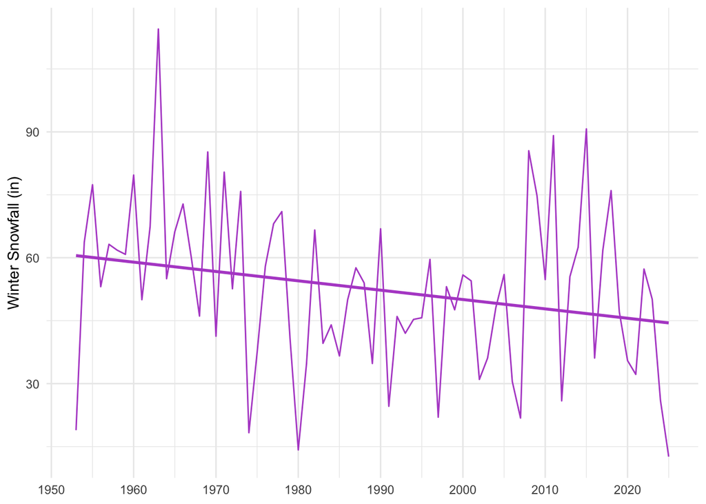

```r
# plot the winter snowfall over time
snow_trend_plot <- ggplot(climate_winter, aes(season_year)) +
  geom_line(aes(y = snow), color = "mediumorchid3") +
  geom_smooth(aes(y = snow), method = "lm", color = "mediumorchid3", se = FALSE) +

  labs(y="Winter Snowfall (in)", x="Year") +

# make breaks for every 10 years on the x axis
   scale_x_continuous(
    breaks = seq(1950, 2020, by = 10),
    labels = seq(1950, 2020, by = 10)
  ) +

  theme_minimal() +
  theme(axis.title.x = element_blank())

snow_trend_plot
```

Similar to the previous trend analysis, we applied linear regression to assess the seasonal trends in winter maximum temperature, minimum temperature, and snowfall over time.

```r
# linear regression for tmax, tmin, and snow over time, similar to above
summary(lm(tmax ~ season_year, data = climate_winter))
# slope is 0.051 F/year, and is statistically significant
summary(lm(tmin ~ season_year, data = climate_winter))
# slope is 0.032 F/year, and is not statistically significant
summary(lm(snow ~ season_year, data = climate_winter))
# slope is -0.223 in/year, and is statistically significant
```

## 3.3 Extremes

To investigate extreme climate events, we used the same dataset to examine key metrics related to climate extremes. Specifically, we focused on the number of freezing days, the hottest day of the year, and the return period for flooding events. Freezing days were defined as any day with a **maximum temperature** of 32°F or lower, in order to focus on daytime temperatures and minimize the influence of cold nights. For flooding events in Maine, we defined a reasonable threshold for daily precipitation as **2 inches per day**.

### 3.3.1 Number of freezing days

```r
# calculate the number of freezing days per year
freeze_days <- climate_clean %>%
  mutate(freeze = ifelse(tmax <= 32, 1, 0)) %>% # if tmax is less than or equal to 32, then it's a freezing day
  group_by(year) %>%
  summarise(freeze_days = sum(freeze))
```

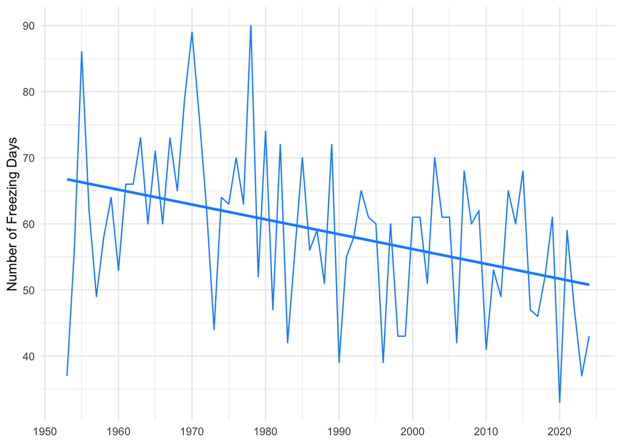

```r
# plot the number of freezing days over time
freezing_plot <- ggplot(freeze_days, aes(year, freeze_days)) +
  geom_line(color = "dodgerblue") +
  geom_smooth(method = "lm", color = "dodgerblue", se = FALSE) +
  labs(y="Number of Freezing Days", x="Year") +

# make breaks for every 10 years on the x axis
   scale_x_continuous(
    breaks = seq(1950, 2020, by = 10),
    labels = seq(1950, 2020, by = 10)
  ) +

  theme_minimal() +
  theme(axis.title.x = element_blank())

freezing_plot
```

### 3.3.2 Hottest day of the year

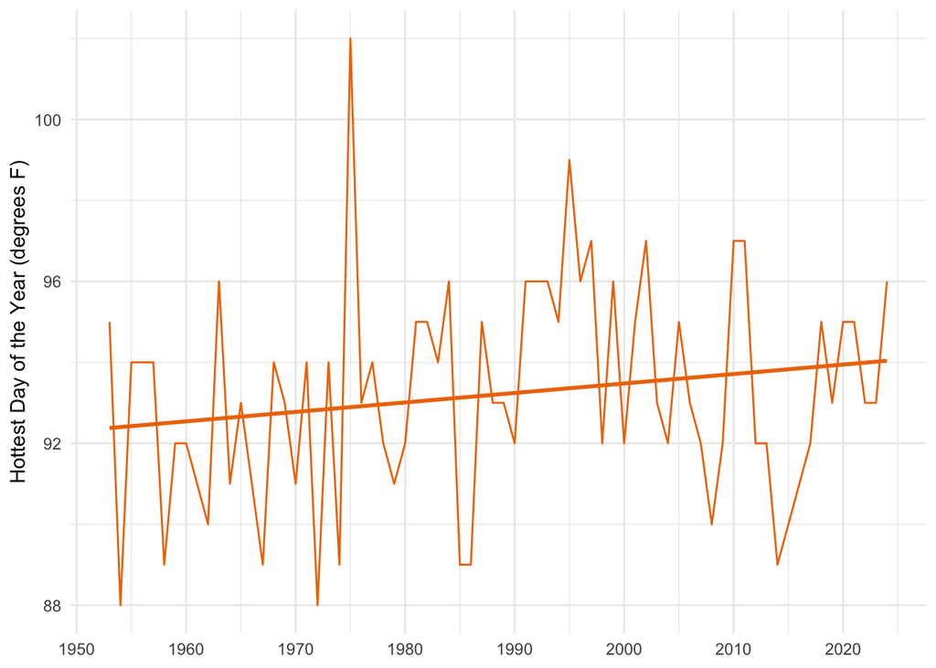

```r
# calculate hottest day of the year
hottest_day <- climate_clean %>%
  group_by(year) %>%
  summarise(hottest = max(tmax))

# plot the hottest days of the year:
hot_plot <- ggplot(hottest_day, aes(year, hottest)) +
  geom_line(color = "darkorange2") +
  geom_smooth(method = "lm", color = "darkorange2", se = FALSE) +
  labs(y="Hottest Day of the Year (degrees F)", x="Year")+

# make breaks for every 10 years on the x axis
   scale_x_continuous(
    breaks = seq(1950, 2020, by = 10),
    labels = seq(1950, 2020, by = 10)
  ) +

  theme_minimal() +
  theme(axis.title.x = element_blank())

hot_plot
```

### 3.3.3 Return period for flooding:

[figure not shown]

```r
# caluclate the return period for flooding events, so if the precipitation is higher then 2 inches a day than it is a 1 and if it is not than it is a 0
flooding_events <- climate_clean %>%
  mutate(flood = ifelse(prcp >= 2, 1, 0)) %>%
  group_by(year) %>%
  summarise(flood_days = sum(flood))

# plot over time
flood_plot <- ggplot(flooding_events, aes(year, flood_days)) +
  geom_line(color = "steelblue") +
  geom_smooth(method = "lm", color = "steelblue", se = FALSE) +
  labs(y="Number of Flooding Days (>= 1 inch/day)", x="Year")+
# make breaks for every 10 years on the x axis
   scale_x_continuous(
    breaks = seq(1950, 2020, by = 10),
    labels = seq(1950, 2020, by = 10)
  ) +

  theme_minimal() +
  theme(axis.title.x = element_blank())

flood_plot
```

```r
# linear regression for freezing days over time
lm_freeze <- lm(freeze_days ~ year, data = freeze_days)
summary(lm_freeze)
# slope is -0.225, and is statistically significant

# linear regression for hottest day of the year over time
lm_hot <- lm(hottest ~ year, data = hottest_day)
summary(lm_hot)
# slope is 0.023, and is not statistically significant

# linear regression for flooding events over time
lm_flood <- lm(flood_days ~ year, data = flooding_events)
summary(lm_flood)
# slope is 0.012 and is not statistically significant
```

### 3.3.4 Extreme events results:

The linear regression analysis for freezing days revealed a significant negative trend, with a decrease of approximately 0.225 days below 32°F per year. In contrast, the analysis for the hottest day of the year showed positive trend of 0.023°F though it was not statistically significant. Similarly, the regression for flooding events indicated an increase of 0.012 flood days per years, but was not statistically significant.

# 4 Discussion